# Bridging the Gap: A Data-Driven Approach to Enhancing Educational Equity and Performance

## CHAPTER 1.0 INTRODUCTION

This project explores the relationship between student demographics, socioeconomic factors, and educational outcomes. It aims to uncover insights into disparities in student average performance. The analysis focuses on the gender disparity, race/ethnicity, parental education levels, lunch status, and the completion of test preparation courses and it's impart on study performance. Through data visualization and in-depth analysis, the project seeks to offer actionable recommendations for educational stakeholders to implement targeted interventions, policies, and practices that promote equity and excellence in education.

### 1.1 AUDIENCE-(To Whom This Report Is For?)

In the context of this analysis, the communication is directed towards educational administrators,parents,students, policymakers, and educators. These stakeholders are pivotal in shaping educational strategies, policies, and teaching methodologies. They have the interest to initiate changes based on insights derived from data analysis. Understanding that this audience is deeply invested in improving educational outcomes and equity, the common ground lies in the mutual interest in utilizing data-driven insights to enhance student performance and address disparities.

This audience is likely to value clear, evidence-based recommendations that can be translated into actionable policies or classroom strategies. They perceive data analysis not just as a report of findings but as a tool for informed decision-making that can lead to tangible improvements in educational systems.

### 1.2 OBJECTIVE

The primary goal is for the audience to recognize the multifaceted factors influencing student performance, including gender disparities, racial/ethnic differences, the impact of socioeconomic status, the role of parental education, and the effectiveness of test preparation courses. By highlighting these factors, the aim is to:

1. **Inform** stakeholders of the existing disparities and areas requiring attention within the educational system.
2. **Encourage** the implementation of targeted interventions designed to support underperforming and disadvantaged student groups.
3. **Advocate** for policies that ensure equitable access to educational resources, including test preparation courses and support services.
4. **Promote** parental and community engagement in supporting students' education, emphasizing the importance of a collaborative approach to education.

### 1.3 How Can The Data Help Make A Compelling Point?

Here’s how data is utilized to strengthen the message:

1. **Visualization:** Graphical representations of data make complex information accessible and engaging, highlighting key trends and disparities at a glance.
2. **Comparison and Correlation:** Demonstrating how different variables (e.g., gender, race/ethnicity, lunch status) correlate with student performance offers a clearer understanding of the areas that require targeted interventions.
3. **Insight Extraction:** Beyond mere statistics, the analysis delves into the implications of the data, offering insights that translate into actionable recommendations for stakeholders.
4. **Storytelling:** The data is not just presented; it’s woven into a narrative that connects with the audience's interests and responsibilities, illustrating how the insights can be leveraged to make informed decisions and enact positive changes in the educational landscape.

## CHAPTER 2.0 DATA EXPLORATION

### 2.1.0 INTEGRATING ESSENTIAL LIBRARIES AND LOADING DATA

```python
import pandas as pd
import numpy as np
import matplotlib.pyplot as plt
import seaborn as sns
%matplotlib inline
sns.set()
sns.set_style("white")
sns.set_palette("Blues_d")
from IPython.display import display, HTML

# Disable scrolling for all outputs
display(HTML("<style>.output_scroll { height: auto !important; }</style>"))
```

```python
data=pd.read_csv("study_performance[1].csv")
data.head()
```

|  | gender | race_ethnicity | parental_level_of_education | lunch | test_preparation_course | math_score | reading_score | writing_score |
| --- | --- | --- | --- | --- | --- | --- | --- | --- |
| 0 | female | group B | bachelor's degree | standard | none | 72 | 72 | 74 |
| 1 | female | group C | some college | standard | completed | 69 | 90 | 88 |
| 2 | female | group B | master's degree | standard | none | 90 | 95 | 93 |
| 3 | male | group A | associate's degree | free/reduced | none | 47 | 57 | 44 |
| 4 | male | group C | some college | standard | none | 76 | 78 | 75 |

### 2.2.0. DATA INFORMATION AND DESCRIPTION

```python
data.info()
```

```
<class 'pandas.core.frame.DataFrame'>
RangeIndex: 1000 entries, 0 to 999
Data columns (total 8 columns):
 #   Column                       Non-Null Count  Dtype
---  ------                       --------------  -----
 0   gender                       1000 non-null   object
 1   race_ethnicity               1000 non-null   object
 2   parental_level_of_education  1000 non-null   object
 3   lunch                        1000 non-null   object
 4   test_preparation_course      1000 non-null   object
 5   math_score                   1000 non-null   int64
 6   reading_score                1000 non-null   int64
 7   writing_score                1000 non-null   int64
dtypes: int64(3), object(5)
memory usage: 62.6+ KB
```

The dataset contains information on students' performance across three subjects: math, reading, and writing. The dataset is divided into categorical and numerical datatypes:

**Categorical Datatype**

*gender:* The student's gender (male/female).

*race_ethnicity:* Categorized into groups (e.g., group A, group B, group c, etc.).

*parental_level_of_education:* Describes the highest level of education attained by the student's parents.

*lunch:* Type of lunch program (standard,free/reduced), possibly indicating socioeconomic status.

*test_preparation_course:* Indicates whether the student completed a test preparation course (none,completed).

**Numerical Datatype**

*math_score:* The student's score in math.

*reading_score:* The student's score in reading.

*writing_score:* The student's score in writing.

```python
data.notnull().value_counts().sum()
```

```
1000
```

There are no null values. The data is clean hence no data cleaning

```python
data.describe()
```

|  | math_score | reading_score | writing_score |
| --- | --- | --- | --- |
| count | 1000.00000 | 1000.000000 | 1000.000000 |
| mean | 66.08900 | 69.169000 | 68.054000 |
| std | 15.16308 | 14.600192 | 15.195657 |
| min | 0.00000 | 17.000000 | 10.000000 |
| 25% | 57.00000 | 59.000000 | 57.750000 |
| 50% | 66.00000 | 70.000000 | 69.000000 |
| 75% | 77.00000 | 79.000000 | 79.000000 |
| max | 100.00000 | 100.000000 | 100.000000 |

*Count:* There are 1,000 observations for each subject.

*Mean:* The average scores are fairly close across subjects, with reading having the highest average (69.17), followed by writing (68.05), and math having the lowest average score (66.09). The overall mean score is 67.77, indicating a general trend of similar performance across subjects.

*Standard Deviation (std):* Reading has the lowest standard deviation (14.60), implying scores are more tightly clustered around the mean, suggesting more consistent performance among students in reading. Math and writing have slightly higher standard deviations (15.16 and 15.20, respectively), indicating more variability in scores.

*Minimum (min):* The minimum scores show that there's at least one student who didn't score any points in math, while the lowest scores in reading and writing are 17 and 10, respectively. The minimum overall score is 9, indicating that there are students who struggled significantly across all subjects.

*Percentiles (25%, 50%, 75%):* The 25th percentile (lower quartile) shows that a quarter of the students scored 57 or below in math, 59 or below in reading, and 57.75 or below in writing. The median (50th percentile) scores are reasonably close to the mean, indicating a somewhat symmetric distribution of scores. The 75th percentile (upper quartile) shows that the top 25% of students scored 77 or above in math, 79 or above in reading and writing, pointing to higher performance in the latter subjects.

*Maximum (max):* The maximum scores indicate that there are top-performing students in each subject scoring perfect 100s.

## CHAPTER 3. DATA EXPLANATION

### 3.1.0 Gender Differences in Academic Performance

**Focus:** Comparison of average performance between genders across subjects.

This insight sparks a deeper investigation into the factors contributing to this divide. It may reflect differences in educational opportunities, societal expectations, or learning environments that are more conducive to one gender over the other.

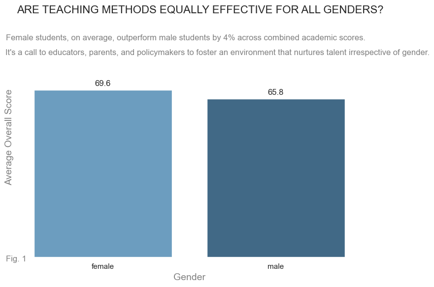

```python
# Calculate the overall score by averaging math, reading, and writing scores
data['overall_score'] = data[['math_score', 'reading_score', 'writing_score']].mean(axis=1)


def remove_frame():
    for spine in plt.gca().spines.values():
        spine.set_visible(False)

def remove_ticks():
    plt.tick_params(axis ='x',bottom =False)
    plt.tick_params(axis ='y',left =False, labelleft=False)

# Calculate the mean overall scores by test preparation course status
mean_overall_scores_by_gender = data.groupby('gender')['overall_score'].mean().reset_index()

# Design the bar chart
plt.figure(figsize=(8, 6))
bar = sns.barplot(data=mean_overall_scores_by_gender, x='gender', y='overall_score', palette='Blues_d')
plt.title('ARE TEACHING METHODS EQUALLY EFFECTIVE FOR ALL GENDERS?', loc='left',fontsize=16)
plt.ylabel('Average Overall Score',color='gray', fontsize=14)
plt.xlabel('Gender',color='gray', fontsize=14)
plt.ylim(0, 100)

# Directly label the bars with their values
for p in bar.patches:
    bar.annotate(format(p.get_height(), '.1f'),
                  (p.get_x() + p.get_width() / 2., p.get_height()),
                  ha = 'center', va = 'center',
                  xytext = (0, 9),
                  textcoords = 'offset points', fontsize=12)

plt.tight_layout()

# Introduce a compelling narrative
plt.figtext(0.53, .85, "Female students, on average, outperform male students by 4% across combined academic scores.",
            ha="center", fontsize=12,color='gray', bbox={"facecolor":"white", "alpha":0.5, "pad":5})
plt.figtext(0.61, .8, "It's a call to educators, parents, and policymakers to foster an environment that nurtures talent irrespective of gender.",
            ha="center", fontsize=12,color='gray', bbox={"facecolor":"white", "alpha":0.5, "pad":5})
plt.figtext(0.1, .1, "Fig. 1",
            ha="center", fontsize=12,color='gray', bbox={"facecolor":"white", "alpha":0.5, "pad":5})
remove_frame()
remove_ticks()
plt.show()
```

The narrative in Fig. 1 here isn't about triumph or deficiency but about understanding and addressing the educational needs of all students. It prompts questions such as:

1. Are teaching methods equally effective for all genders?
2. Do male students have the same support and encouragement as their female counterparts?
3. Are there cultural or societal biases that might be influencing these outcomes?

Answering these questions can guide the development of more inclusive educational strategies that ensure all students have equal opportunities to reach their full potential.The higher scores among female students could also be influenced by gender-specific attitudes towards learning and education or the presence of role models that inspire academic pursuit. It's a call to educators, parents, and policymakers to foster an environment that nurtures talent irrespective of gender, challenging stereotypes and supporting all students in their academic endeavors.

### 3.2.0. Overall Performance: Impact of Test Preparation

**The Power of Preparation:** The second insight reveals a tale of dedication and the undeniable benefits of preparation. Students who completed a test preparation course showcased significantly higher average overall scores compared to their peers who did not. This finding underscores a critical message: investment in preparation can pave the way for academic success, advocating for the implementation of accessible and effective test preparation resources for all students.

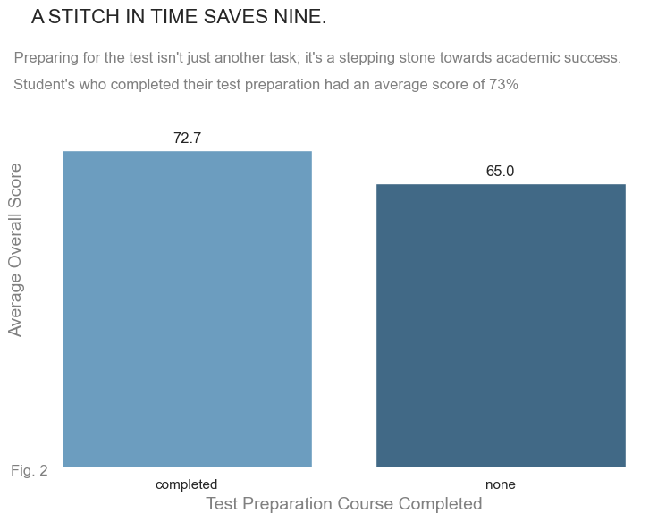

```python
# Calculate the overall score by averaging math, reading, and writing scores
data['overall_score'] = data[['math_score', 'reading_score', 'writing_score']].mean(axis=1)

# Calculate the mean overall scores by test preparation course status
mean_overall_scores_by_prep = data.groupby('test_preparation_course')['overall_score'].mean().reset_index()

# Design the bar chart
plt.figure(figsize=(8, 6))
bar = sns.barplot(data=mean_overall_scores_by_prep, x='test_preparation_course', y='overall_score', palette='Blues_d')
plt.title("A STITCH IN TIME SAVES NINE.",loc='left', fontsize=16)
plt.ylabel('Average Overall Score',color='gray', fontsize=14)
plt.xlabel('Test Preparation Course Completed',color='gray', fontsize=14)
plt.ylim(0, 100)

# Directly label the bars with their values
for p in bar.patches:
    bar.annotate(format(p.get_height(), '.1f'),
                  (p.get_x() + p.get_width() / 2., p.get_height()),
                  ha = 'center', va = 'center',
                  xytext = (0, 9),
                  textcoords = 'offset points', fontsize=12)

plt.tight_layout()

# Introduce a compelling narrative
plt.figtext(0.5, .87, ' Preparing for the test isn\'t just another task; it\'s a stepping stone towards academic success.',
            ha="center", fontsize=12,color='gray', bbox={"facecolor":"white", "alpha":0.5, "pad":5})
plt.figtext(0.43, .82, 'Student\'s who completed their test preparation had an average score of 73%',
            ha="center", fontsize=12,color='gray', bbox={"facecolor":"white", "alpha":0.5, "pad":5})
plt.figtext(0.1, .1, "Fig. 2",
            ha="center", fontsize=12,color='gray', bbox={"facecolor":"white", "alpha":0.5, "pad":5})
remove_frame()
remove_ticks()
plt.show()
```

The bar chart (Fig.2) illustrates the significant impact of completing a test preparation course on students' overall academic performance, combining their scores in math, reading, and writing. Students who completed the test preparation course achieved higher overall scores than those who did not engage in preparation activities.

This visual story emphasizes a critical message: "A stitch in time saves nine." By dedicating time and effort to prepare for tests, students can significantly enhance their academic achievements. This insight serves as a potent reminder of the value of preparation and its role as a cornerstone of success. It encourages educators, policymakers, and students themselves to prioritize and invest in effective preparation strategies to unlock their full potential.

### 3.3.0. Influence of Parental Education on Overall Performance

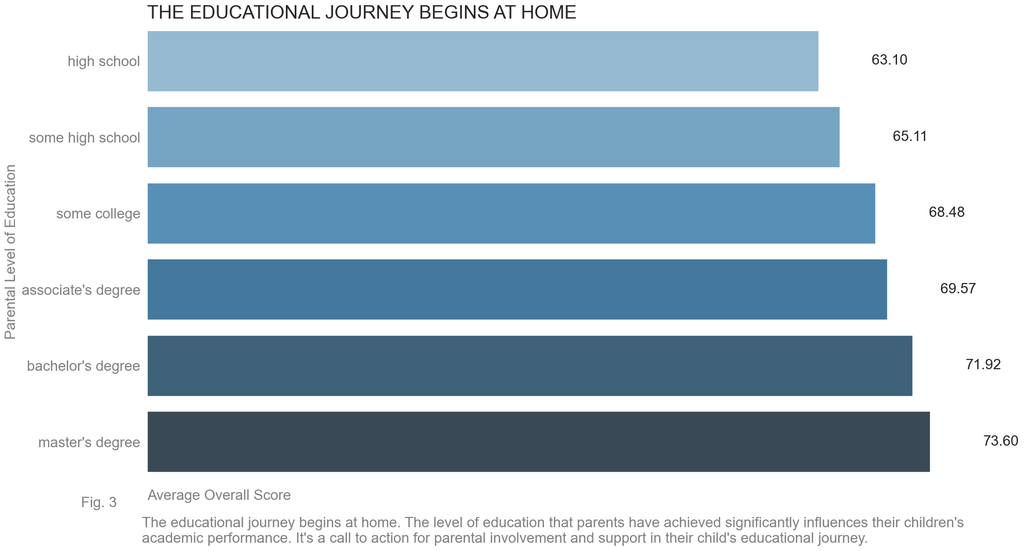

```python
# Calculate the mean overall scores by parental level of education
mean_overall_scores_by_parent_edu = data.groupby('parental_level_of_education')['overall_score'].mean().sort_values().reset_index()

# Design the bar chart for parental level of education
plt.figure(figsize=(20, 10))
bar = sns.barplot(data=mean_overall_scores_by_parent_edu, x='overall_score', y='parental_level_of_education',palette='Blues_d')
plt.title('THE EDUCATIONAL JOURNEY BEGINS AT HOME', fontsize=26, loc= 'left')
plt.xlabel('Average Overall Score',color='gray', fontsize=20, loc='left')
plt.ylabel('Parental Level of Education', color='gray',fontsize=20)
plt.yticks(color='gray',fontsize=20)

# Directly label the bars with their values
for p in bar.patches:
    width = p.get_width()
    plt.text(5 + width, p.get_y() + p.get_height()/2., '{:1.2f}'.format(width), va='center', fontsize=20)

bar.set_xticklabels([])
bar.xaxis.set_ticks_position('none')
plt.tight_layout()

# Introduce a compelling narrative
plt.text(
    -0.5, 6.3,  # Coordinates for the placement of the text
    "The educational journey begins at home. The level of education that parents have "
    "achieved significantly influences their children's academic performance. "
    "It's a call to action for parental involvement and support in their child's educational journey.",
    fontsize=20, color='grey', wrap=True
)
plt.figtext(0.1, .01, "Fig. 3",
            ha="center", fontsize=20,color='gray', bbox={"facecolor":"white", "alpha":0.5, "pad":5})
remove_frame()
plt.show()
```

This visualization brings to light a crucial narrative: "The educational journey begins at home." The education level of parents not only reflects in their children's performance but also highlights the importance of parental involvement and support in education. It acts as a clarion call for parents to engage actively in their children's educational journeys, providing encouragement, resources, and an environment conducive to learning.

This story encourages communities, educators, and policymakers to recognize and support family engagement initiatives as a vital component of educational success, ensuring every child has the support needed to reach their full potential.

### 3.4.0 Socioeconomic Influence on Overall Performance

**The Socioeconomic Divide:** The comparison of overall average scores between students receiving standard versus free/reduced lunch revealed a stark disparity, serving as a proxy for socioeconomic status. Students with access to standard lunch options consistently outperformed their counterparts, painting a poignant picture of how economic challenges can impede academic achievement. This insight calls for a collective reflection on the need to bridge the socioeconomic divide, ensuring that every student has the support and resources necessary to thrive academically.

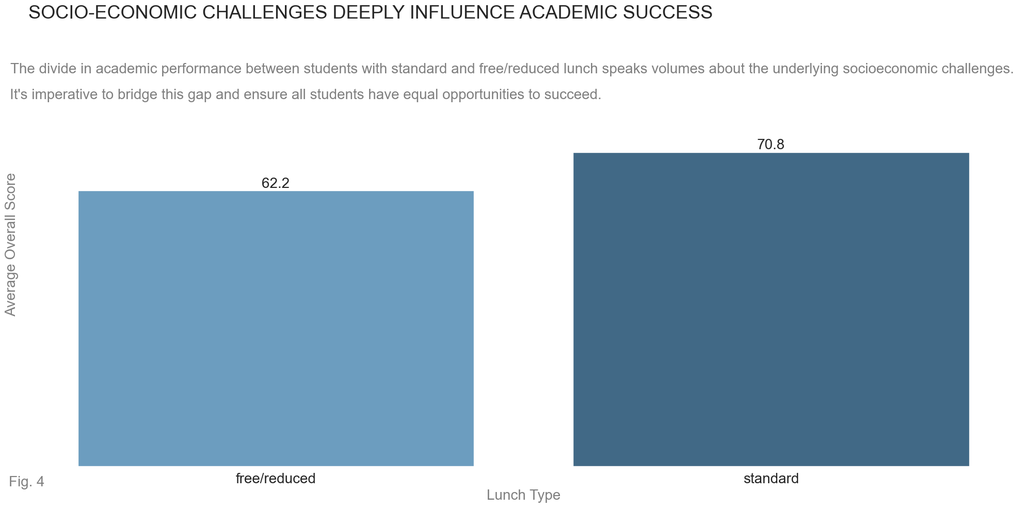

```python
# Calculate the mean overall scores by lunch type
mean_overall_scores_by_lunch = data.groupby('lunch')['overall_score'].mean().reset_index()

# Design the bar chart for lunch type
plt.figure(figsize=(20, 10))
bar = sns.barplot(data=mean_overall_scores_by_lunch, x='lunch', y='overall_score', palette='Blues_d')
plt.title('SOCIO-ECONOMIC CHALLENGES DEEPLY INFLUENCE ACADEMIC SUCCESS',loc='left', fontsize=26)
plt.ylabel('Average Overall Score', color='gray',fontsize=20)
plt.xlabel('Lunch Type',color='gray', fontsize=20)
plt.ylim(0, 100)
plt.xticks(fontsize=20)
# Directly label the bars with their values
for p in bar.patches:
    bar.annotate(format(p.get_height(), '.1f'),
                  (p.get_x() + p.get_width() / 2., p.get_height()),
                  ha = 'center', va = 'center',
                  xytext = (0, 9),
                  textcoords = 'offset points', fontsize=20)

bar.set_yticklabels([])
bar.yaxis.set_ticks_position('none')


plt.tight_layout()

# Introduce a compelling narrative
plt.figtext(0.5, 0.85, 'The divide in academic performance between students with standard and free/reduced lunch speaks volumes about the underlying socioeconomic challenges.',
           ha="center", fontsize=20, bbox={"facecolor":"white", "alpha":0.5, "pad":5}, color='gray')
plt.figtext(0.3, 0.8, 'It\'s imperative to bridge this gap and ensure all students have equal opportunities to succeed.',
           ha="center", fontsize=20, bbox={"facecolor":"white", "alpha":0.5, "pad":5}, color='gray')
plt.figtext(0.03, .05, "Fig. 4",
            ha="center", fontsize=20,color='gray', bbox={"facecolor":"white", "alpha":0.5, "pad":5})
remove_frame()

plt.show()
```

The bar chart (Fig. 4) presents a stark visual representation of the socioeconomic divide in academic performance, as indicated by the type of lunch students receive. It vividly illustrates that students with standard lunch options, often a marker of higher socioeconomic status, achieve higher overall scores compared to those receiving free or reduced lunch.

This visualization narrates a critical aspect of our education system- "The underlying socioeconomic challenges deeply influence academic success." The disparity in performance based on lunch type serves as a powerful reminder of the broader social inequalities affecting students' opportunities and outcomes. It emphasizes the urgent need for interventions and policies aimed at leveling the playing field, ensuring that every student, regardless of their socioeconomic background, has access to the resources and support necessary to thrive academically.

### 3.5.0 Performance Variations by Race/Ethnicity

**Diversity in Performance:** Lastly, the exploration of the average scores across different race and ethnicity groups unveiled variations in academic outcomes. This diversity in performance serves as a reminder of the complex interplay between culture, community, and education. It emphasizes the critical need for culturally responsive teaching methods and policies that recognize and cater to the unique backgrounds and experiences of each student.

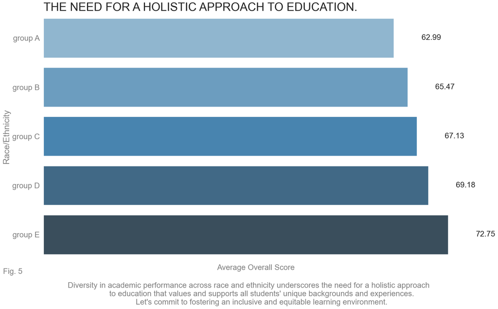

```python
# Calculate the mean overall scores by race/ethnicity
mean_overall_scores_by_race = data.groupby('race_ethnicity')['overall_score'].mean().sort_values().reset_index()

# Design the bar chart for race/ethnicity
plt.figure(figsize=(18, 10))
bar = sns.barplot(data=mean_overall_scores_by_race, x='overall_score', y='race_ethnicity', palette='Blues_d')
plt.title('THE NEED FOR A HOLISTIC APPROACH TO EDUCATION.', fontsize=30, loc='left')
plt.xlabel('Average Overall Score',color='gray', fontsize=20)
plt.ylabel('Race/Ethnicity',color='gray', fontsize=22)
plt.yticks(color='gray',fontsize=20)

# Directly label the bars with their values
for p in bar.patches:
    width = p.get_width()
    plt.text(5 + width, p.get_y() + p.get_height()/2., '{:1.2f}'.format(width), va='center', fontsize=20)

bar.set_xticklabels([])
bar.xaxis.set_ticks_position('none')

plt.tight_layout()

# Introduce a compelling narrative
plt.figtext(0.5, -0.1,
            """Diversity in academic performance across race and ethnicity underscores the need for a holistic approach
            to education that values and supports all students' unique backgrounds and experiences.
            Let's commit to fostering an inclusive and equitable learning environment.""",
            ha="center", fontsize=20,color='gray', bbox={"facecolor":"white", "alpha":0.5, "pad":5})
plt.figtext(0.03, .01, "Fig. 5",
            ha="center", fontsize=20,color='gray', bbox={"facecolor":"white", "alpha":0.5, "pad":5})
remove_frame()
plt.show()
```

The bar (Fig. 5) chart offers a nuanced look at the variations in academic performance across different race and ethnicity groups, revealing significant differences in average overall scores. This visual insight brings to the forefront the critical conversation around diversity, equity, and inclusion in education. It showcases the need for targeted support and resources that respect and respond to the varied experiences and challenges faced by students from diverse backgrounds.

This visualization tells an essential part of our story: "The need for a holistic approach to education." It stresses the importance of creating an educational environment that not only acknowledges but actively embraces and supports the diversity of its student body. This approach involves implementing policies, curricula, and practices that are inclusive and equitable, ensuring that every student has the opportunity to excel regardless of their race or ethnicity.

# CHAPTER 4.0 DISCUSSION AND CONCLUSION

## 4.1.0 Bridging the Narrative and Action:

The story does not end with the visualization of data; it merely begins. Here are actionable steps aimed at educators, parrents, students, policymakers, and communities:

**Expand Access to Test Preparation:** Recognizing the substantial impact of test preparation on student outcomes, schools and communities should work to provide accessible, high-quality test preparation resources. This could include free test prep courses, online resources, and tutoring services, ensuring that all students, regardless of their socioeconomic status, have the opportunity to prepare effectively.

**Engage Parents in the Educational Journey:** The correlation between parental education levels and student performance highlights the importance of involving parents in the educational process. Schools can offer workshops, resources, and support systems that empower parents to play an active role in their children's education, regardless of their own educational background.

**Address Socioeconomic Disparities:** The stark differences in performance based on lunch type—a proxy for socioeconomic status—call for targeted interventions. Initiatives such as providing nutritious meals, offering financial assistance for educational materials, and creating supportive learning environments can help mitigate the impact of economic challenges on academic success.

**Foster Diversity and Inclusion:** The diversity in performance across race and ethnicity groups emphasizes the need for educational practices that respect and celebrate diversity. Culturally responsive teaching, inclusive curriculum design, and support systems tailored to the unique needs of diverse student populations are crucial steps toward equity.

**Community Collaboration:** Achieving these goals requires a collaborative effort involving schools, families, local organizations, and policymakers. By working together, stakeholders can create a supportive ecosystem that addresses the multifaceted needs of students, paving the way for a more equitable and successful educational landscape.

## 4.2.0 The Call to Action

Our data-driven story, rooted in the principles of storytelling, design thinking, and effective visualization, serves as a call to action. It invites us to reflect on the current state of education, recognize the challenges and disparities that exist, and commit to making meaningful changes. By addressing the highlighted issues, we can work towards an educational system where every student has the opportunity to thrive, irrespective of their background, challenges, or circumstances.

## REFERENCES

1. Jikadara, B., no date. Student Study Performance. [online] Kaggle. Available at: https://www.kaggle.com/datasets/bhavikjikadara/student-study-performance [Accessed 9 March 2024].
2. Knaflic, C.N., 2015. Storytelling with Data: A Data Visualization Guide for Business Professionals. Wiley.
3. VanderPlas, J., 2016. Python Data Science Handbook: Essential Tools for Working with Data. O'Reilly Media.